# Crypto_popgenModule_md

## Read in data

Reading in merged vcf files generated using bcftools merge, containing SNP data from multiple samples. Convert this into a genind object, and assign populations according to the prefix of the sample ID*. Finally, convert into a genpop object.

*this is not optimal since it only works in this instance and assumes that all members of UKH26, for example, belong to the same population. This could be switched out for populations as defined by a text file.

```r
vcf <- read.vcfR( "/home/amorris/BioInf/Parapipe/test_dryrunBIG/GVCFs/merged.vcf", verbose = FALSE )
gind <- vcfR2genind(vcf)
gind
```

```
## /// GENIND OBJECT /////////
##
##  // 55 individuals; 21,577 loci; 22,785 alleles; size: 14 Mb
##
##  // Basic content
##    @tab:  55 x 22785 matrix of allele counts
##    @loc.n.all: number of alleles per locus (range: 1-4)
##    @loc.fac: locus factor for the 22785 columns of @tab
##    @all.names: list of allele names for each locus
##    @ploidy: ploidy of each individual  (range: 2-2)
##    @type:  codom
##    @call: adegenet::df2genind(X = t(x), sep = sep)
##
##  // Optional content
##    - empty -
```

```r
row.names(gind@tab)
```

```
##  [1] "UKH35_4.sorted.bam" "UKH30_2.sorted.bam" "UKH32_1.sorted.bam"
##  [4] "UKH26_4.sorted.bam" "UKH34_3.sorted.bam" "UKH35_1.sorted.bam"
##  [7] "UKH25_1.sorted.bam" "UKH37_2.sorted.bam" "UKH28_4.sorted.bam"
## [10] "UKH37_1.sorted.bam" "UKH26_1.sorted.bam" "UKH23_2.sorted.bam"
## [13] "UKH26_3.sorted.bam" "UKH29_1.sorted.bam" "UKH28_3.sorted.bam"
## [16] "UKH27_2.sorted.bam" "UKH27_3.sorted.bam" "UKH31_4.sorted.bam"
## [19] "UKH32_2.sorted.bam" "UKH32_3.sorted.bam" "UKH31_3.sorted.bam"
## [22] "UKH28_2.sorted.bam" "UKH29_2.sorted.bam" "UKH36_1.sorted.bam"
## [25] "UKH27_4.sorted.bam" "UKH24_3.sorted.bam" "UKH31_2.sorted.bam"
## [28] "UKH35_2.sorted.bam" "UKH28_1.sorted.bam" "UKH29_4.sorted.bam"
## [31] "UKH36_2.sorted.bam" "UKH23_3.sorted.bam" "UKH25_4.sorted.bam"
## [34] "UKH36_3.sorted.bam" "UKH33_2.sorted.bam" "UKH27_1.sorted.bam"
## [37] "UKH32_4.sorted.bam" "UKH33_1.sorted.bam" "UKH26_2.sorted.bam"
## [40] "UKH24_4.sorted.bam" "UKH33_4.sorted.bam" "UKH30_4.sorted.bam"
## [43] "UKH34_4.sorted.bam" "UKH33_3.sorted.bam" "UKH30_3.sorted.bam"
## [46] "UKH35_3.sorted.bam" "UKH25_2.sorted.bam" "UKH29_3.sorted.bam"
## [49] "UKH31_1.sorted.bam" "UKH25_3.sorted.bam" "UKH36_4.sorted.bam"
## [52] "UKH23_4.sorted.bam" "UKH23_1.sorted.bam" "UKH37_3.sorted.bam"
## [55] "UKH37_4.sorted.bam"
```

```r
pops_meta <- sapply(strsplit(as.character(indNames(gind)), "_"), "[[", 1)
df <- data.frame(pops = pops_meta, id = indNames(gind))
df <- df[order(df$id),]
gind@pop <- as.factor(df$pops)
gpop <- genind2genpop(gind)
```

```
##
##  Converting data from a genind to a genpop object...
##
## ...done.
```

```r
gpop
```

```
## /// GENPOP OBJECT /////////
##
##  // 15 populations; 21,577 loci; 22,785 alleles; size: 10.5 Mb
##
##  // Basic content
##    @tab:  15 x 22785 matrix of allele counts
##    @loc.n.all: number of alleles per locus (range: 1-4)
##    @loc.fac: locus factor for the 22785 columns of @tab
##    @all.names: list of allele names for each locus
##    @ploidy: ploidy of each individual  (range: 2-2)
##    @type:  codom
##    @call: genind2genpop(x = gind)
##
##  // Optional content
##    - empty -
```

## Plot data

Run centred, non-scaled PCA on data.

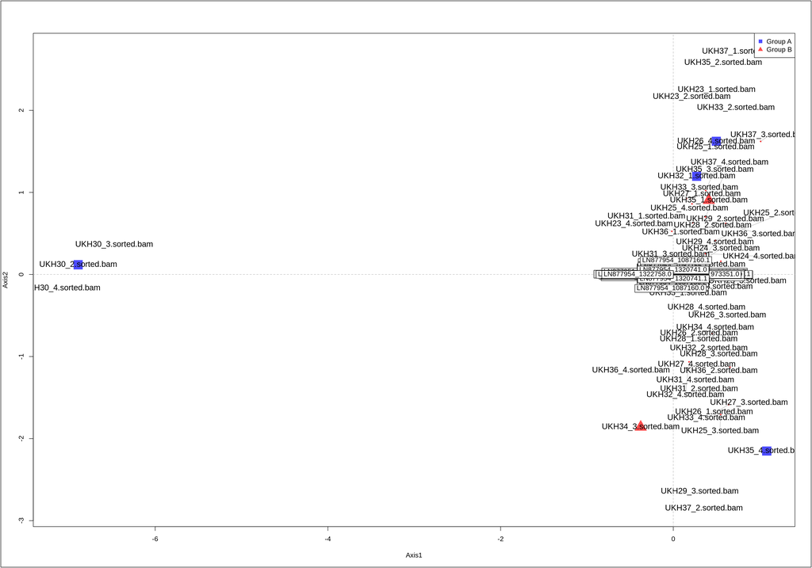

```r
X <- tab(gind, NA.method="mean")
pca1 <- dudi.pca(X,scannf=FALSE,scale=FALSE)
temp <- as.integer(pop(gind))
myCol <- transp(c("blue","red"),.7)[temp]
myPch <- c(15,17)[temp]

plot(pca1$li, col=myCol, cex=3, pch=myPch)

library(wordcloud)
textplot(pca1$li[,1], pca1$li[,2], words=rownames(X), cex=1.2, new=FALSE)

abline(h=0,v=0,col="grey",lty=2)
s.arrow(pca1$c1*.5, add.plot=TRUE)
legend("topright", pch=c(15,17), col=transp(c("blue","red"),.7),
        leg=c("Group A","Group B"), pt.cex=1.2)
```

Generate a dendrogram using distance in Euclidean space

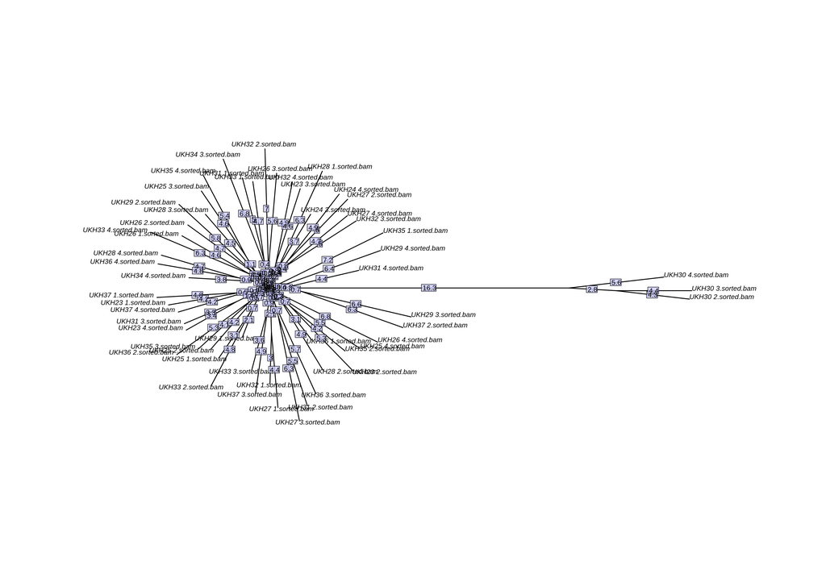

```r
library(ape)
D <- dist(tab(gind))
tre <- nj(D)
par(xpd=TRUE)
plot(tre, type="unrooted", edge.w=2)
edgelabels(tex=round(tre$edge.length,1), bg=rgb(.8,.8,1,.8))
```

Carry out Principle coordinate analysis on these euclidean distances, since they are a more accurate representation of nth dimensional distances in planar space.

```r
pco1 <- dudi.pco(D, scannf=FALSE,nf=2)
```

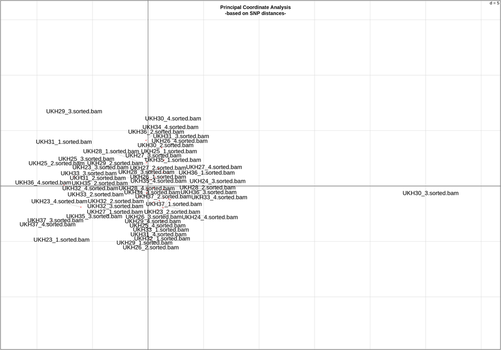

```r
s.label(pco1$li*1.1, clab=0, pch="")
textplot(pco1$li[,1], pco1$li[,2], words=rownames(pco1$li),
cex=1.4, new=FALSE, xpd=TRUE)
title("Principal Coordinate Analysis\n-based on SNP distances-")
```

```r
X <- scaleGen(gind, NA.method="mean")
```

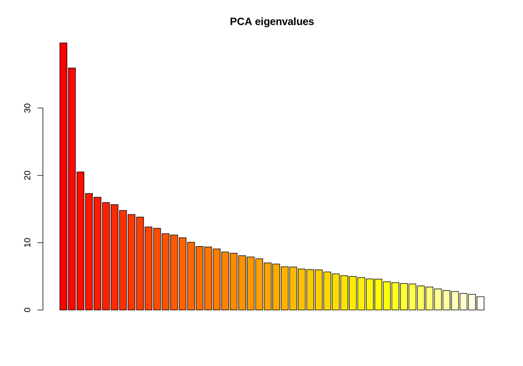

```r
pca1 <- dudi.pca(X,cent=FALSE,scale=FALSE,scannf=FALSE,nf=3)
barplot(pca1$eig[1:50],main="PCA eigenvalues", col=heat.colors(50))
```

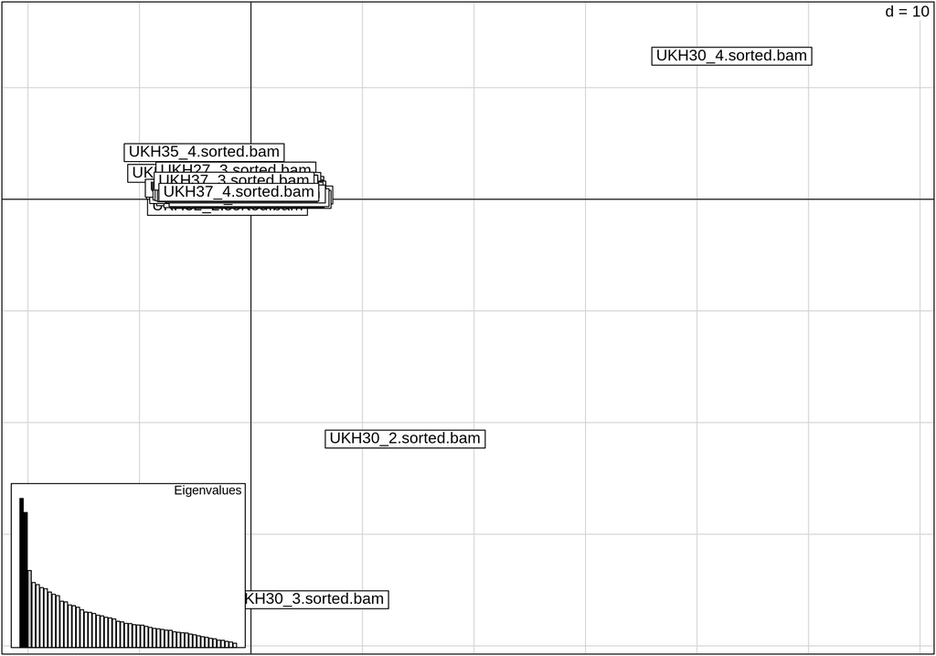

```r
s.label(pca1$li)
add.scatter.eig(pca1$eig, 3,1,2)
```

Improvement to PCA plot by using s.class to represent both the genotypes and inertia ellipses for populations.

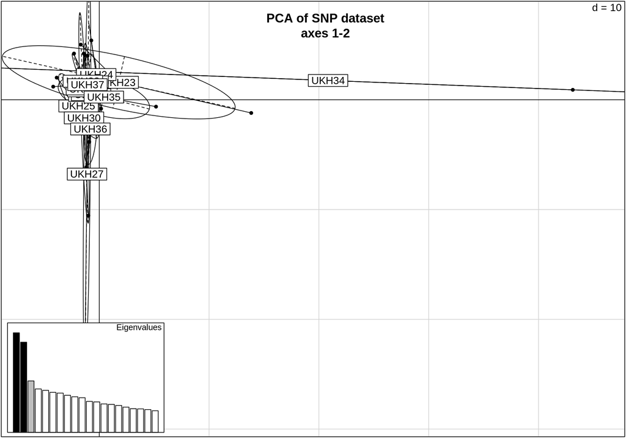

```r
s.class(pca1$li,pop(gind),xax=1,yax=3,sub="PCA 1-2",csub=2)
title("PCA of SNP dataset\naxes 1-2")
add.scatter.eig(pca1$eig[1:20],nf=3,xax=1,yax=2)
```

and on the third axis

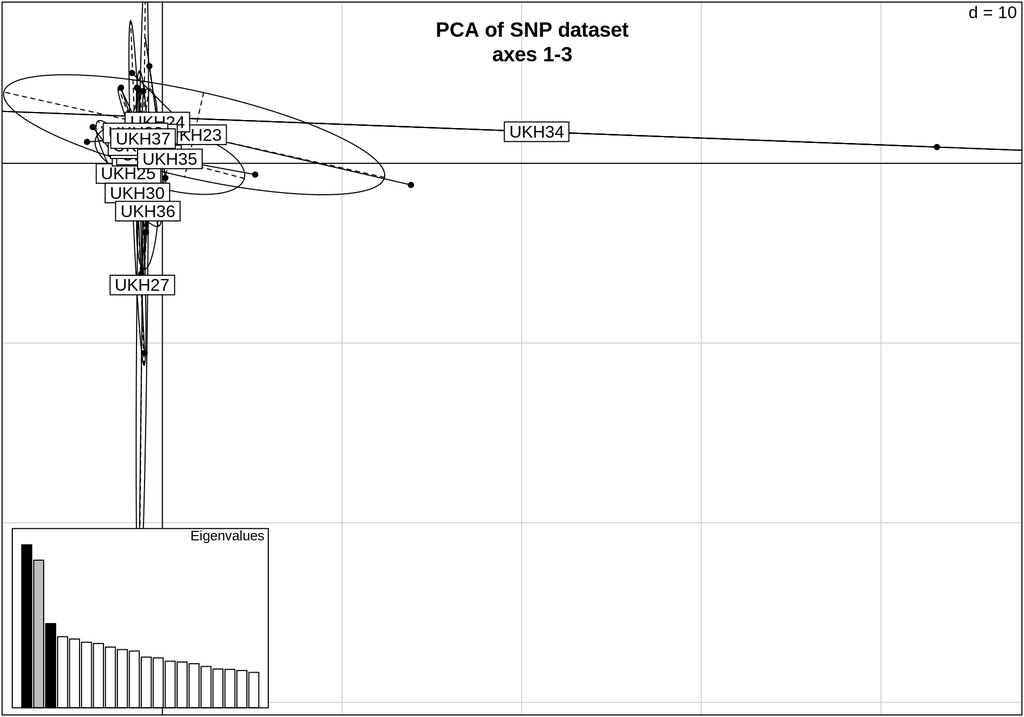

```r
s.class(pca1$li,pop(gind),xax=1,yax=3,sub="PCA 1-3",csub=2)
title("PCA of SNP dataset\naxes 1-3")
add.scatter.eig(pca1$eig[1:20],nf=3,xax=1,yax=3)
```

Colourisation of the PCA

```r
col <- funky(15)
s.class(pca1$li, pop(gind),xax=1,yax=3, col=transp(col,.6), axesell=FALSE,
cstar=0, cpoint=3, grid=FALSE)
```

[figure not shown]

Recode principle components to be represented on the RGB scale

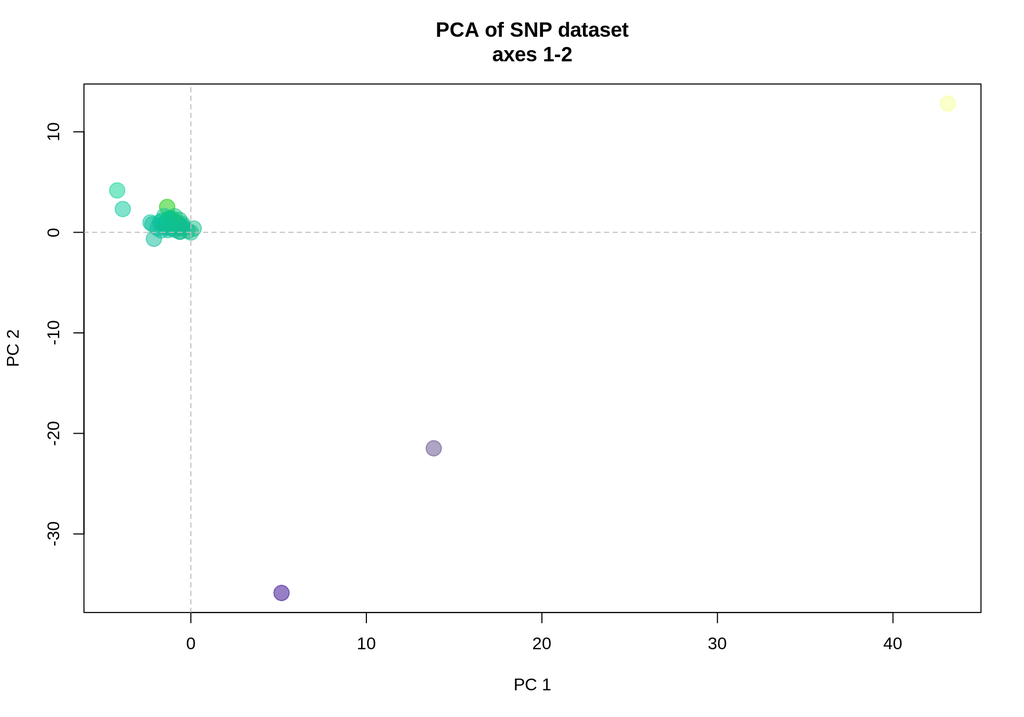

```r
colorplot(pca1$li, pca1$li, transp=TRUE, cex=3, xlab="PC 1", ylab="PC 2")
title("PCA of SNP dataset\naxes 1-2")
abline(v=0,h=0,col="grey", lty=2)
```

and on the third axis

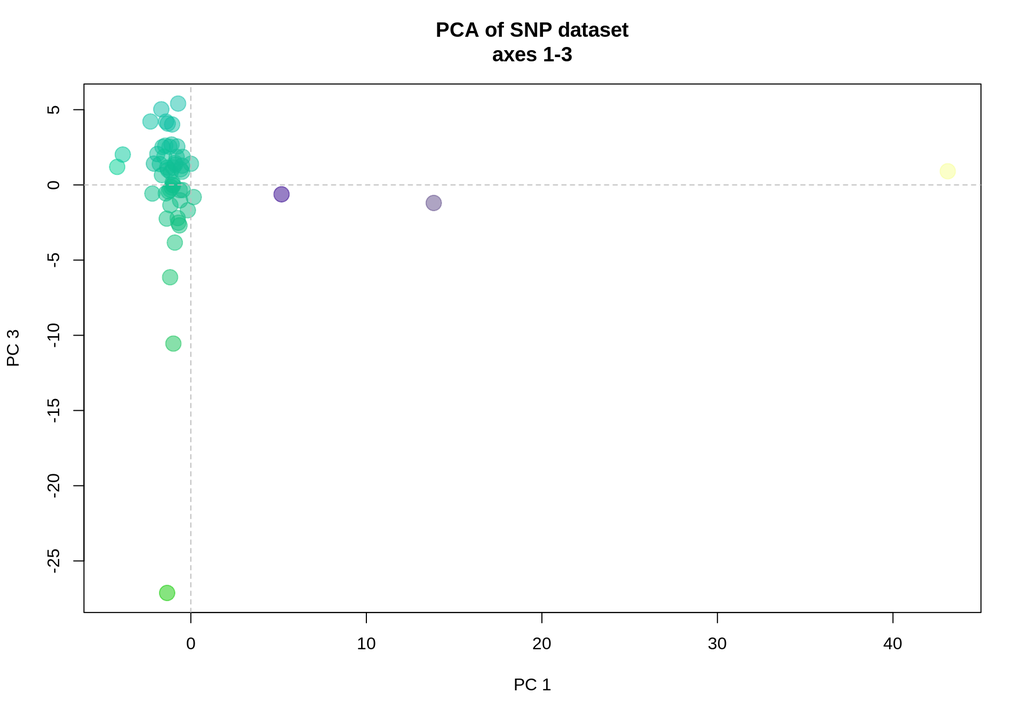

```r
colorplot(pca1$li[c(1,3)], pca1$li, transp=TRUE, cex=3, xlab="PC 1", ylab="PC 3")
title("PCA of SNP dataset\naxes 1-3")
abline(v=0,h=0,col="grey", lty=2)
```